# 22M04Vinnik-hw2

Vinnik Ekaterina

2024-03-02

# ДЗ 2. Анализ данных стоимости медобслуживания пациентов (Medical Cost Personal Datasets)

## Винник Екатерина Петровна, 22.М04

```r
library(readr)
options(readr.show_col_types = FALSE)
insurance_data <- read_csv("data/insurance.csv")
print(insurance_data)
```

```
## # A tibble: 1,338 × 7
##      age sex      bmi children smoker region    charges
##    <dbl> <chr>  <dbl>    <dbl> <chr>  <chr>       <dbl>
##  1    19 female  27.9        0 yes    southwest  16885.
##  2    18 male    33.8        1 no     southeast   1726.
##  3    28 male    33          3 no     southeast   4449.
##  4    33 male    22.7        0 no     northwest  21984.
##  5    32 male    28.9        0 no     northwest   3867.
##  6    31 female  25.7        0 no     southeast   3757.
##  7    46 female  33.4        1 no     southeast   8241.
##  8    37 female  27.7        3 no     northwest   7282.
##  9    37 male    29.8        2 no     northeast   6406.
## 10    60 female  25.8        0 no     northwest  28923.
## # ℹ 1,328 more rows
```

## Построение гистограмм частот непрерывных признаков

В датасете имеются следующие непрерывные признаки:

- возраст (age)
- индекс массы тела (bmi)
- расходы (charges)

Построим гистограмммы частот для всех этих признаков:

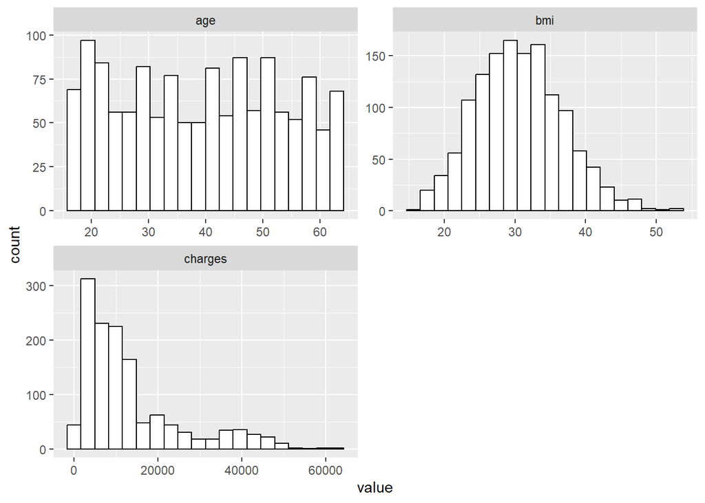

```r
library(ggplot2)
library(dplyr)
library(tidyr)

insurance_data %>% select('age', 'bmi', 'charges') %>% pivot_longer(1:3, values_to="value", names_to="names") %>% ggplot() + geom_histogram(aes(x = value), bins = 20, colour = "black", fill = "white") + facet_wrap(~ names, scales = "free", ncol=2)
```

На гистограммах выше можно отметить, что среди множеств значений `bmi` и `charges` есть три наблюдения, которые имеют значения, большие, чем основная масса наблюдений.

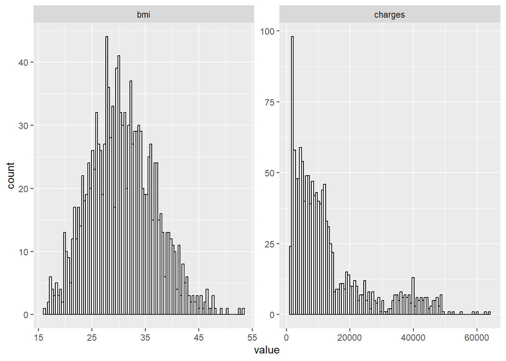

```r
insurance_data %>% select(bmi, charges)  %>% tidyr::pivot_longer(1:2, values_to="value", names_to="names") %>%
  ggplot() + geom_histogram(aes(x = value), bins = 100, colour = "black", fill = "white") + facet_wrap(~ names, scales = "free", ncol=2)
```

Найдем номера этих наблюдений:

```r
which(insurance_data$charges > 59000)
```

```
## [1]  544 1231 1301
```

```r
which(insurance_data$bmi > 50)
```

```
## [1]  848 1048 1318
```

Таким образом, для признака `charges` это номера 544, 1231, 1301, а для признака `bmi` это номера 848, 1048, 1318. При построении модели машинного обучения может быть осмысленно счесть эти значения выбросами.

## Сравнение выраженности непрерывных признаков между группами мужчин и женщин

Сравним, насколько выражены непрерывные признаки среди группы мужчин по сравнению с группой женщин. Для сравнения воспользуемся статистическим критерием. Будем использовать t-критерий Стьюдента, так как признаки, измеренные в выборке, являются непрерывными, а ключевая переменная пол (т.е. главная переменная для решения поставленной задачи) — качественной.

### Индекс массы тела (bmi)

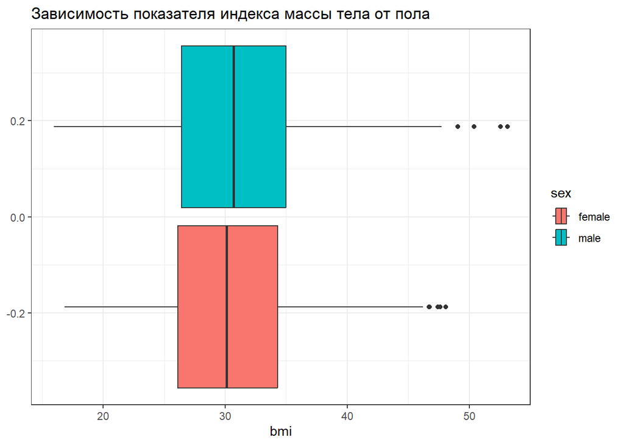

```r
ggplot(aes(x=bmi, fill = sex), data=insurance_data) +
  geom_boxplot() +
  labs(x = "bmi",title="Зависимость показателя индекса массы тела от пола") +
  theme_bw()
```

**Нулевая гипотеза**: среднее значение индекса массы тела не отличается для групп мужчин и женщин.

```r
t.test(insurance_data$bmi ~ insurance_data$sex, paired=FALSE)
```

```
##
##  Welch Two Sample t-test
##
## data:  insurance_data$bmi by insurance_data$sex
## t = -1.697, df = 1336, p-value = 0.08992
## alternative hypothesis: true difference in means between group female and group male is not equal to 0
## 95 percent confidence interval:
##  -1.21895043  0.08819153
## sample estimates:
## mean in group female   mean in group male
##             30.37775             30.94313
```

Так как p-значение (0.09) больше выбранного уровня значимости (0.05), нулевая гипотеза принимается. Таким образом, различия между рассматриваемыми группами мужчин и женщин по показателю индекс массы тела не являются значимыми.

### Возраст (age)

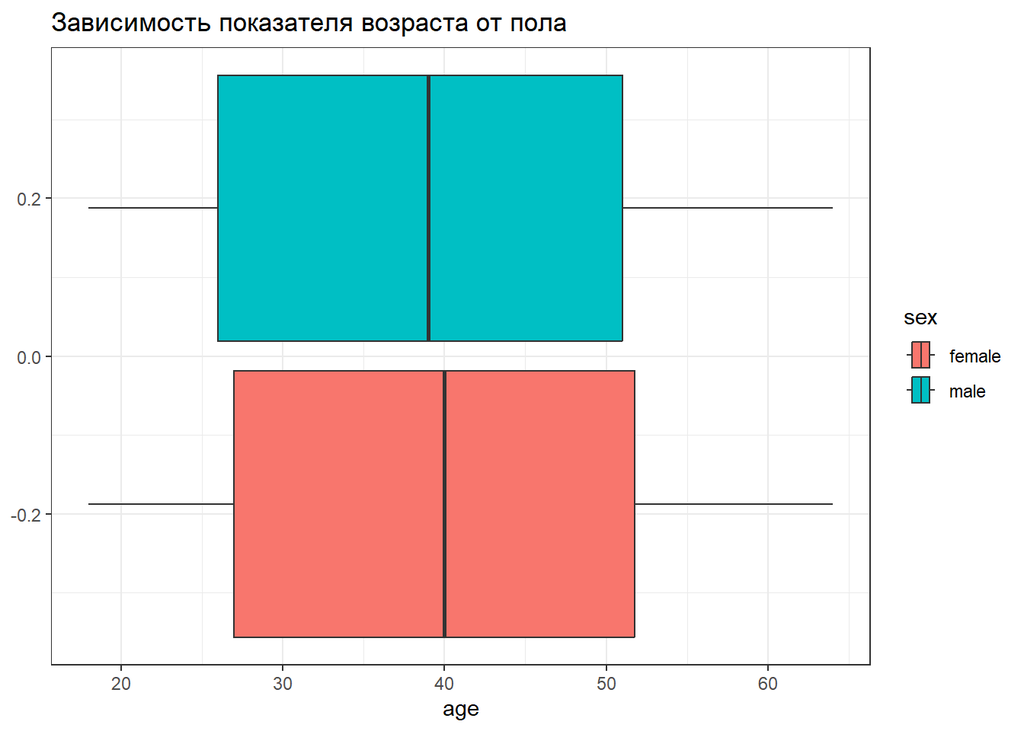

```r
ggplot(aes(x=age, fill = sex), data=insurance_data) +
  geom_boxplot() +
  labs(x = "age",title="Зависимость показателя возраста от пола") +
  theme_bw()
```

**Нулевая гипотеза**: среднее значение возраста не различается для групп мужчин и женщин.

```r
t.test(insurance_data$age ~ insurance_data$sex, paired=FALSE)
```

```
##
##  Welch Two Sample t-test
##
## data:  insurance_data$age by insurance_data$sex
## t = 0.76247, df = 1335.4, p-value = 0.4459
## alternative hypothesis: true difference in means between group female and group male is not equal to 0
## 95 percent confidence interval:
##  -0.9214814  2.0932042
## sample estimates:
## mean in group female   mean in group male
##             39.50302             38.91716
```

Так как p-значение (0.45) больше выбранного уровня значимости (0.05), нулевая гипотеза принимается. Таким образом, различия между рассматриваемыми группами мужчин и женщин по показателю возраст не являются значимыми.

### Расходы (charges)

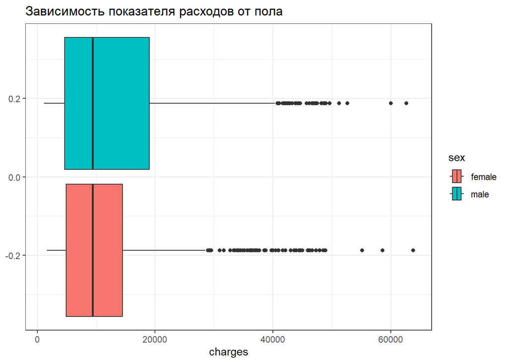

```r
ggplot(aes(x=charges, fill = sex), data=insurance_data) +
  geom_boxplot() +
  labs(x = "charges",title="Зависимость показателя расходов от пола") +
  theme_bw()
```

**Нулевая гипотеза**: среднее значение расходов не отличается для групп мужчин и женщин.

```r
t.test(insurance_data$charges ~ insurance_data$sex, paired=FALSE)
```

```
##
##  Welch Two Sample t-test
##
## data:  insurance_data$charges by insurance_data$sex
## t = -2.1009, df = 1313.4, p-value = 0.03584
## alternative hypothesis: true difference in means between group female and group male is not equal to 0
## 95 percent confidence interval:
##  -2682.48932   -91.85535
## sample estimates:
## mean in group female   mean in group male
##             12569.58             13956.75
```

Так как p-значение (0.04) меньше выбранного уровня значимости (0.05), нулевая гипотеза отвергается. Таким образом, различия между рассматриваемыми группами мужчин и женщин по показателю расходы являются значимыми.

### Выводы

Таким образом, можно сказать, что:

- различия между мужчинами и женщинами по непрерывному признаку расходы (charges) являются значимыми
- различия по остальным признакам: возраст (age), индекс массы тела (bmi) не являются значимыми

## Анализ коррелляций непрерывных признаков

Посмотрим на корреляции непрерывных признаков.

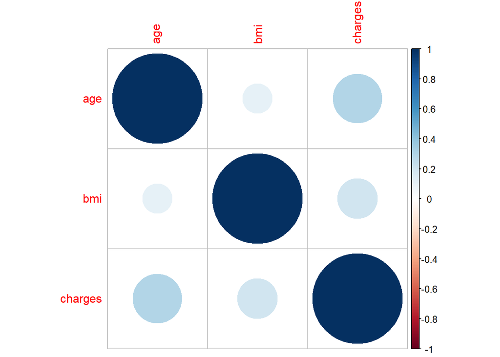

```r
library(corrplot)
plotCor <- corrplot(cor(insurance_data %>% select('age','bmi','charges')))
```

Из матрицы корреляций видно, что:

- признаки age и charges коррелируют;
- также коррелируют и признаки bmi и charges;
- остальные пары признаков коррелируют в меньшей степени.

Используем статистический вывод для установления зависимости коррелирующих переменных. Положим уровень значимости равным 0.05.

#### Корреляция переменных age и charges

**Нулевая гипотеза**: коэффициент корреляции между переменными `age` и `charges` равен нулю.

```r
cor.test(insurance_data$age, insurance_data$charges)
```

```
##
##  Pearson's product-moment correlation
##
## data:  insurance_data$age and insurance_data$charges
## t = 11.453, df = 1336, p-value < 2.2e-16
## alternative hypothesis: true correlation is not equal to 0
## 95 percent confidence interval:
##  0.2494139 0.3470381
## sample estimates:
##       cor
## 0.2990082
```

Статистика критерия равна 11.45 (1336 степеней свободы), p-value < 0.05. Таким образом, гипотеза о равенстве нулю коэффициента корреляции не принимается на выбранном уровне значимости.

#### Корреляция переменных bmi и charges

**Нулевая гипотеза**: коэффициент корреляции между переменными `bmi` и `charges` равен нулю.

```r
cor.test(insurance_data$bmi, insurance_data$charges)
```

```
##
##  Pearson's product-moment correlation
##
## data:  insurance_data$bmi and insurance_data$charges
## t = 7.3966, df = 1336, p-value = 2.459e-13
## alternative hypothesis: true correlation is not equal to 0
## 95 percent confidence interval:
##  0.1463052 0.2492822
## sample estimates:
##      cor
## 0.198341
```

Статистика критерия равна 7.39 (1336 степеней свободы), p-value < 0.05. Таким образом, гипотеза о равенстве нулю коэффициента корреляции не принимается на выбранном уровне значимости.

#### Корреляция переменных age и bmi

**Нулевая гипотеза**: коэффициент корреляции между переменными `age` и `bmi` равен нулю.

```r
cor.test(insurance_data$age, insurance_data$bmi)
```

```
##
##  Pearson's product-moment correlation
##
## data:  insurance_data$age and insurance_data$bmi
## t = 4.0181, df = 1336, p-value = 6.194e-05
## alternative hypothesis: true correlation is not equal to 0
## 95 percent confidence interval:
##  0.05600895 0.16191463
## sample estimates:
##       cor
## 0.1092719
```

Статистика критерия равна 4.02 (1336 степеней свободы), p-value < 0.05. Таким образом, гипотеза о равенстве нулю коэффициента корреляции не принимается на выбранном уровне значимости.